# JW_R_Project

Jamie Wandzilak

April 20, 2019

# Figure 1

Comparison of research spending on 3 types of energy from 1997 to 2018.

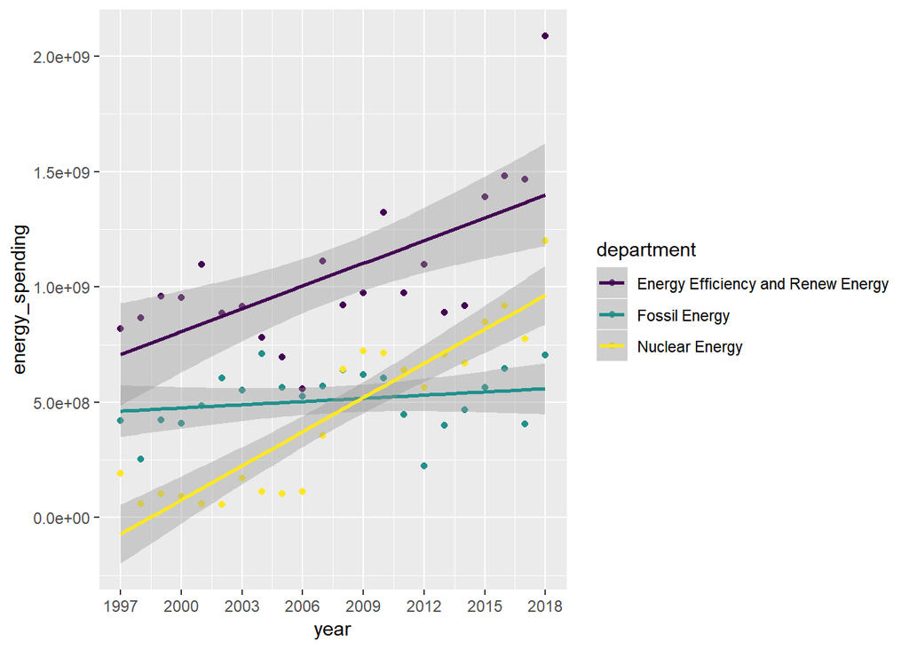

## Types of Energy

When looking at research spending of energy types it is important to look at how spending has changed over time. Energy spending for fossil fuels has remained relatively even over the past 22 years. Research spending for both nuclear energy and for energy efficiency/renewable energy has shown trends of increasing over the last 22 years.

# Figure 2

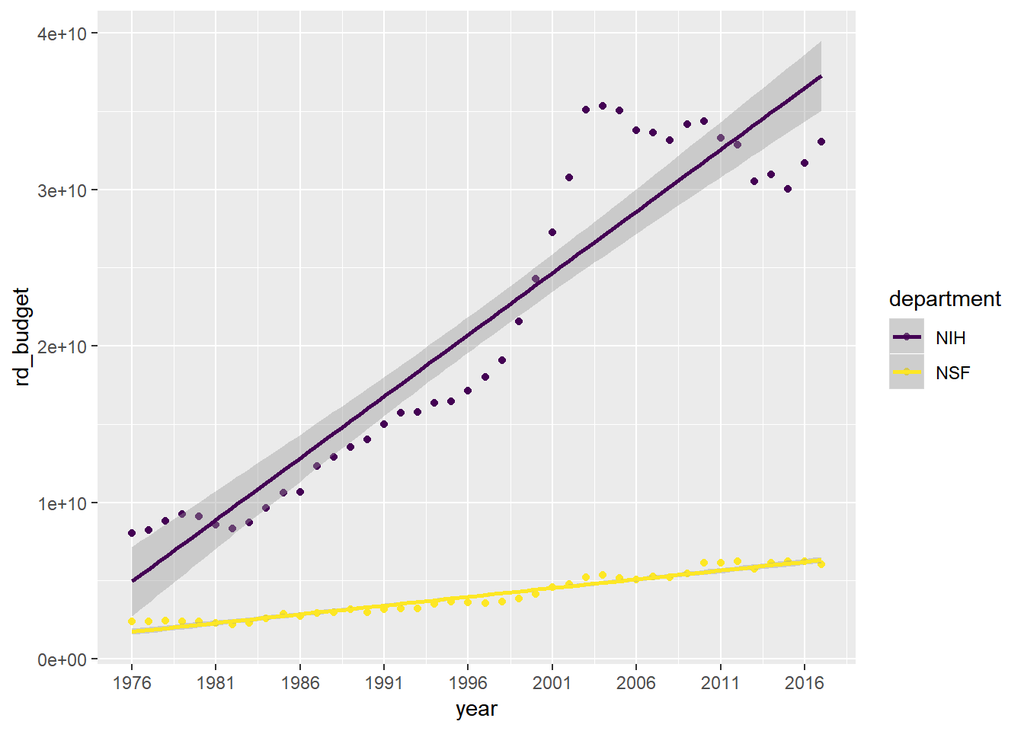

## NSF vs NIH

The NSF and the NIH are two of the biggest funding providers for science research. Both departments have experienced upward trends in research and development spending over the time frame of this data set. This trend seems to be more variable for NIH with an r-squared value of 0.8790541 and less variable for NSF with an r-squared value of 0.9475748.

# Figure 3

Comparing research and development budgets of science based deparatments with the research spending of the Department of Defense.

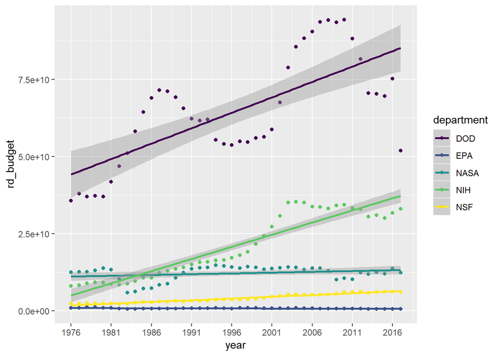

## Department of Defense vs Science Departments

# Figure 4

Changes in federal spending across departments during the years of George W. Bush’s presidency

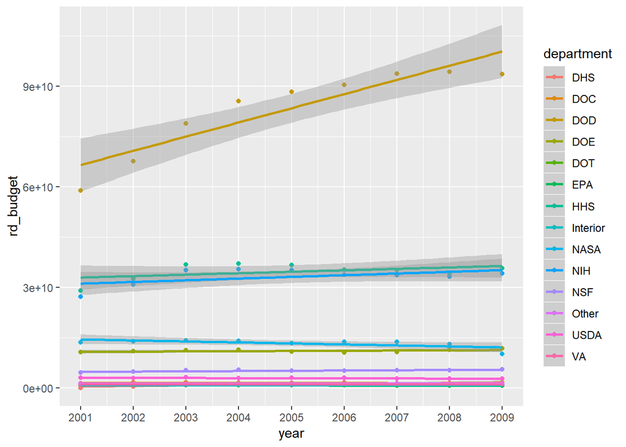

## Spending During Bush’s Presidency

When looking at federal spending it is important to look at changes that take place within the governing body. During the years of George W. Bush’s presidency spending remains fairly constant for all departments besides the department of defense (DOD). In the 8 years of Bush’s presidency there was a trend of increased spending for the research and development budget of the DOD supported by an r-squared value of 0.8370667. This trend was likely due to world events that influenced increased investment into the department of defense.

# Figure 5

Changes in federal spending across departments during the years of Barack Obama’s presidency

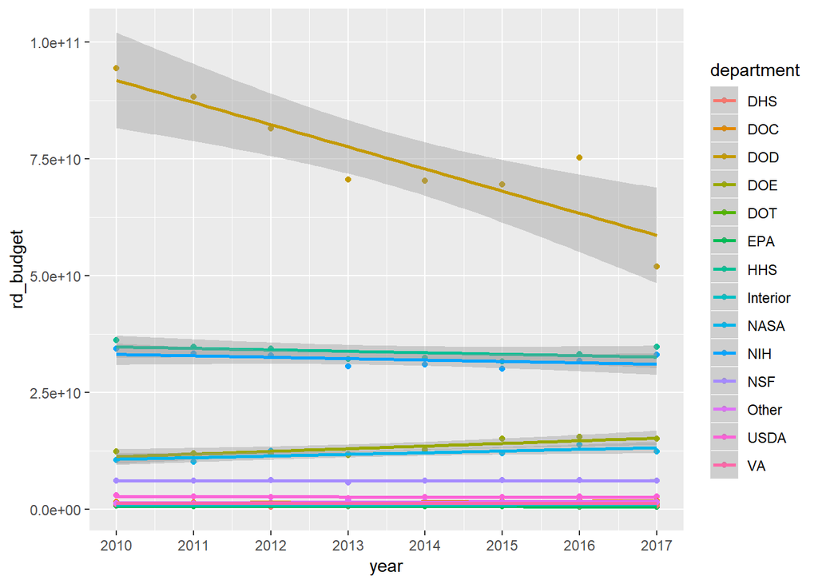

## Spending During Obama’s Presidency

# Figure 6

Comparing total DOD budgets between the Bush presidency and the Obama presidency

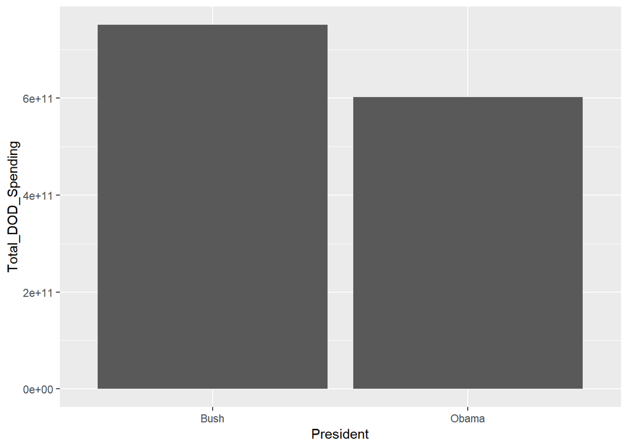